# Data Cleaning

## Description of the Data

Data were scraped from the web into a SQLite3 database with two tables: one containing show results and one containing pedigree data.

```r
library(tidyverse)
library(RSQLite)
library(lubridate)
conn <- dbConnect(RSQLite::SQLite(), "dressage.db")

ped <- dbGetQuery(conn,'SELECT * FROM pedigree')
shows <- dbGetQuery(conn, 'SELECT * FROM show_results')
```

```r
head(ped)
```

```
##   horse_id        dam_ueln       sire_ueln dam_id sire_id        dob    sex
## 1  105AH62 276409090078202 276409090081903   <NA>    <NA> 23/04/2007 Female
## 2  102ZI90 276433330566801 276333332243993   <NA>    <NA> 07/07/2005 Female
## 3  103HX90 276431314606900 276333330471993   <NA>    <NA> 14/02/2006   Male
## 4  103CM31 276341410477388 276343430476299   <NA>    <NA> 12/02/2004 Female
## 5 DEN40739 276331310958893 276309090304085   <NA>    <NA> 24/04/2003   Male
## 6  105BZ34 276373732023391 276341410479692   <NA>    <NA> 17/05/2009 Female
##        horse_ueln
## 1 276409090042107
## 2 276433330826405
## 3 276431310648406
## 4 276441411396304
## 5 208333200301452
## 6 276431310562909
```

```r
dim(ped)
```

```
## [1] 1081    8
```

The pedigree table contains 1081 rows and 8 columns. Each row represents a horse, who is identified either by the column `horse_id` or the column `horse_ueln`. The goal of tidying is to obtain a pedigree dataframe where every individual is contained within their own row. This includes individuals who are at the outset only included in the `sire_id`/`sire_ueln` or `dam_id`/`dam_ueln` columns. Duplicate data is likely to be a problem due to the scraping method used to obtain the data - duplicate rows should be identified and removed. NA should be consistently used to represent missing values (e.g. absence of recorded parents).`sex` should be recoded as 0 for females, 1 for males, and NA for missing data. `dob` refers to the horse’s date of birth, which is given in one of two formats in the raw dataframe: DD/MM/YYYY or DD/MM/YYYY (age). These will be tidied into year of birth for each individual (YYYY).

```r
head(shows)
```

```
##   location event_type                            comp_title horse_id
## 1      NED      CDI-W GP FS - Grand Prix Freestyle to Music  102ZI90
## 2      NED      CDI-W                       GP - Grand Prix  102ZI90
## 3      SWE      CDI5* GP FS - Grand Prix Freestyle to Music  102ZI90
## 4      SWE      CDI5*                       GP - Grand Prix  102ZI90
## 5      GER      CDI-W GP FS - Grand Prix Freestyle to Music  102ZI90
## 6      GER      CDI-W                       GP - Grand Prix  102ZI90
##               dob  sex rider_id position  score
## 1 15 - 07/07/2005 Mare 10011389        1 90.280
## 2 15 - 07/07/2005 Mare 10011389        1 83.565
## 3 15 - 07/07/2005 Mare 10011389        2 89.310
## 4 15 - 07/07/2005 Mare 10011389        1 83.652
## 5 15 - 07/07/2005 Mare 10011389        2 87.240
## 6 15 - 07/07/2005 Mare 10011389        1 81.565
```

```r
dim(shows)
```

```
## [1] 18033     9
```

The shows table has 18033 rows and 9 columns. Each row represents a single show result for a single horse/rider combination. In this table, horses are described only by `horse_id`, and thus this is the only way to link them to the pedigree table. Riders are identified by their unique `rider_id`. `sex` and `dob` must be encoded as they are in the pedigree table and will be used as a quality control measures to ensure agreement between records with the same `horse_id` in both tables. `shows` also contains: the country code of the nation in which the show took place (`location`), the level of event (`event_type`), the title of the competition (`comp_title`), the position of the combination (`position`) and their score (`score`).

## Clean the Pedigree Table

First, I will replace blank cells with NA and remove any rows which appear multiple times. 76 duplicate rows are removed.

```r
ped$horse_id <- str_trim(str_remove(ped$horse_id, "\\(.*"))

ped <- as_tibble(ped)
ped[ped==''] <- NA

ped <- ped %>%
  mutate_all(str_trim) %>%
  distinct()

dim(ped)
```

```
## [1] 1005    8
```

### Clean Sex Column

Next, I will standardise the sexes and obtain year of birth. Although the distinction between geldings and stallions may be informative, 140 male individuals are not distinguished as stallion or gelding. For now, I will collapse all males into a single category (1).

```r
table(ped$sex)
```

```
##
##   Female  Gelding     Male     Mare Stallion
##       13      351      140      267      210
```

```r
ped$sex_raw <- ped$sex
ped_sex_raw <- ped

ped <- ped %>%
  mutate(sex=replace(sex, sex == "Mare", "0")) %>%
  mutate(sex=replace(sex, sex == "Stallion", "1")) %>%
  mutate(sex=replace(sex, sex == "Gelding", "1")) %>%
  mutate(sex=replace(sex, sex == "Male", "1")) %>%
  mutate(sex=replace(sex, sex == "Female", "0"))

table(ped$sex)
```

```
##
##   0   1
## 280 701
```

```r
sum(is.na(ped$sex))
```

```
## [1] 24
```

```r
ped$sex_raw <- NULL
ped <- ped %>%
  distinct()
```

This leaves us with 280 females, 701 males, and 24 individuals missing sex.

### Create yob Column

I obtain the year of birth for each individual from the `dob` column.

```r
tail(ped$dob)
```

```
## [1] "18/04/2006 (14 y)" "05/06/2006 (14 y)" "22/05/2006 (14 y)"
## [4] "07/03/2006 (14 y)" "01/05/1997 (23 y)" "21/05/2008 (12 y)"
```

```r
ped$dob <- str_trim(str_remove(ped$dob, "\\(.*"))

tail(ped$dob)
```

```
## [1] "18/04/2006" "05/06/2006" "22/05/2006" "07/03/2006" "01/05/1997"
## [6] "21/05/2008"
```

```r
ped$yob <- year(dmy(ped$dob))

head(ped$yob, n = 20)
```

```
##  [1] 2007 2005 2006 2004 2003 2009 2002 2006 2004 2004 2008 2004 2008 2007 2007
## [16] 2007 2002 2008 2006 2008
```

```r
head(ped$dob, n = 20)
```

```
##  [1] "23/04/2007" "07/07/2005" "14/02/2006" "12/02/2004" "24/04/2003"
##  [6] "17/05/2009" "21/04/2002" "25/03/2006" "29/05/2004" "16/03/2004"
## [11] "17/01/2008" "25/02/2004" "30/04/2008" "05/06/2007" "06/05/2007"
## [16] "30/04/2007" "20/05/2002" "09/07/2008" "27/05/2006" "17/05/2008"
```

```r
ped$dob <- NULL
```

### Dealing with Duplication

Although initially I filtered out all identical rows, there is still a problem with duplicate IDs and UELNs arising in the data. 35 UELNs are present more than once in `horse_ueln`, and 41 IDs are present more than once in `horse_id`. I am going to remove this issue before proceeding any further.

```r
sum(table(ped$horse_id) > 1)
```

```
## [1] 41
```

```r
sum(table(ped$horse_ueln) > 1)
```

```
## [1] 35
```

```r
getDupIds <- function(df, id_type) {
  list <- df %>%
    count(!!sym(id_type)) %>%
    filter(n > 1) %>%
    pull(id_type)

  list <- list[!is.na(list)]

  if (length(list) != 0) {
    return(list)
  } else {
    return("No duplicate ids.")
  }
}

dup_uelns <- getDupIds(ped, "horse_ueln")
dup_ids <- getDupIds(ped, "horse_id")

length(dup_uelns)
```

```
## [1] 35
```

```r
length(dup_ids)
```

```
## [1] 41
```

```r
ped %>%
  filter(horse_id %in% dup_ids) %>%
  arrange(horse_id)
```

```
## # A tibble: 85 x 8
##    horse_id dam_ueln      sire_ueln     dam_id sire_id sex   horse_ueln      yob
##    <chr>    <chr>         <chr>         <chr>  <chr>   <chr> <chr>         <dbl>
##  1 102YA19  276331314439~ <NA>          <NA>   <NA>    1     276331310826~  1999
##  2 102YA19  276333330025~ <NA>          <NA>   <NA>    1     276331310826~  1999
##  3 102ZI90  276433330566~ 276333332243~ <NA>   <NA>    0     276433330826~  2005
##  4 102ZI90  276333330880~ 276333332243~ <NA>   <NA>    0     276433330826~  2005
##  5 103EM30  <NA>          528003199205~ <NA>   <NA>    1     528003200211~  2002
##  6 103EM30  <NA>          528003199205~ <NA>   <NA>    1     528003200211~  2002
##  7 103HO85  276333330355~ 276331310826~ <NA>   <NA>    1     276433330482~  2006
##  8 103HO85  <NA>          276331310826~ <NA>   <NA>    1     276433330482~  2006
##  9 103HX90  276431314606~ 276333330471~ <NA>   <NA>    1     276431310648~  2006
## 10 103HX90  276333330150~ 276333330471~ <NA>   <NA>    1     276431310648~  2006
## # ... with 75 more rows
```

```r
ped %>%
  filter(horse_ueln %in% dup_uelns) %>%
  arrange(horse_ueln)
```

```
## # A tibble: 71 x 8
##    horse_id dam_ueln      sire_ueln     dam_id sire_id sex   horse_ueln      yob
##    <chr>    <chr>         <chr>         <chr>  <chr>   <chr> <chr>         <dbl>
##  1 105DD91  208333200102~ 528003200201~ <NA>   <NA>    1     208333DW0700~  2007
##  2 105DD91  528003199103~ 528003200201~ <NA>   <NA>    1     208333DW0700~  2007
##  3 104AW69  208333DW0403~ 528003200407~ <NA>   <NA>    1     208333DW0800~  2008
##  4 104AW69  528003199600~ 528003200407~ <NA>   <NA>    1     208333DW0800~  2008
##  5 104LO87  208333199505~ 276433330655~ <NA>   <NA>    1     208333DW0804~  2008
##  6 104LO87  276333330017~ 276433330655~ <NA>   <NA>    1     208333DW0804~  2008
##  7 GER20663 276331310183~ <NA>          <NA>   GER065~ 1     276331310590~  1993
##  8 GER20663 276333330025~ <NA>          <NA>   GER065~ 1     276331310590~  1993
##  9 102YA19  276331314439~ <NA>          <NA>   <NA>    1     276331310826~  1999
## 10 102YA19  276333330025~ <NA>          <NA>   <NA>    1     276331310826~  1999
## # ... with 61 more rows
```

I prepare a series of functions that identify where duplicated rows differ (NA in both rows is counted as a match).

```r
getDupRows <- function(id, df, id_type) {
  df <- df[!is.na(df[[id_type]]),]
  return(df[df[[id_type]]==id,])
}

makeOutputMatrix <- function(df) {
  matrix(0, ncol = 3, nrow = ncol(df),
         dimnames = list(c(colnames(df)), c("Match", "Different", "NA")))
}

identifyMatches <- function(row1, row2, outmatrix) {
  for (lll in 1:ncol(row1)) {
    if (is.na(row1[,lll] == row2[,lll])) {
      if (is.na(row1[,lll]) & is.na(row2[,lll])) {
        outmatrix[lll, "Match"] <- outmatrix[lll, "Match"] + 1
      } else {
        outmatrix[lll, "NA"] <- outmatrix[lll, "NA"] + 1
      }
    } else {
      if (row1[,lll] == row2[,lll]) {
        outmatrix[lll, "Match"] <- outmatrix[lll, "Match"] + 1
      } else {
        outmatrix[lll, "Different"] <- outmatrix[lll, "Different"] + 1
      }
    }
  }
  return(outmatrix)
}

compareDupRows <- function(id, df, id_type) {
  outmatrix <- makeOutputMatrix(df)
  duprows <- getDupRows(id, df, id_type)

  if (nrow(duprows) <= 1) {
    return("ID is not a duplicate.")
  }

  for (iii in 1:nrow(duprows)) {
    for (jjj in 1:nrow(duprows)) {
      if (iii < jjj) {
        outmatrix <- identifyMatches(duprows[iii,], duprows[jjj,], outmatrix)
      }
    }
  }
  return(outmatrix)
}

compareAllDupRows <- function(dupids, df, id_type) {
  outmatrix <- makeOutputMatrix(df)
  for (id in dupids) {
    temp <- compareDupRows(id, df, id_type)
    outmatrix <- outmatrix + temp
  }
  return(outmatrix)
}

pass1 <- compareAllDupRows(dup_ids, ped, "horse_id") + compareAllDupRows(dup_uelns, ped, "horse_ueln")
pass1
```

```
##            Match Different NA
## horse_id      84         0  0
## dam_ueln      16        40 28
## sire_ueln     84         0  0
## dam_id        80         0  4
## sire_id       78         0  6
## sex           84         0  0
## horse_ueln    75         1  8
## yob           84         0  0
```

An ID may have one record that contains `dam_ueln`, `horse_ueln`, `sire_id`, or `dam_id` but is NA for this field in the duplicated record. In such cases, it makes sense to remove the record that has the least information. More concerning is the inconsistency in dam uelns: where the same horse is recorded twice, with two different dams listed.

```r
# split dup uelns and ids into those that differ by NA only and those with different data
identifyRowsDifferingbyNA <- function(id, dupRows) {
  if (nrow(dupRows) <= 1) {
    return("ID is not a duplicate.")
  }

  for (iii in 1:nrow(dupRows)) {
    for (jjj in 1:nrow(dupRows)) {
      if (iii < jjj & sum(is.na(dupRows[1,])) != sum(is.na(dupRows[2,]))) {
        return(id)
      }
    }
  }
}

getIdsDifferingByNA <- function(id_list, df, id_type) {
  idsDifferentByNA <- c()
  for (id in id_list) {
    dupRows <- getDupRows(id, df, id_type)
    idsDifferentByNA <- append(idsDifferentByNA, identifyRowsDifferingbyNA(id, dupRows), after = length(idsDifferentByNA))
  }
  return(idsDifferentByNA)
}

ids_differbyna <- getIdsDifferingByNA(dup_ids, ped, "horse_id")
ped %>%
  filter(horse_id %in% ids_differbyna) %>%
  arrange(horse_id)
```

```
## # A tibble: 45 x 8
##    horse_id dam_ueln      sire_ueln     dam_id sire_id sex   horse_ueln      yob
##    <chr>    <chr>         <chr>         <chr>  <chr>   <chr> <chr>         <dbl>
##  1 103HO85  276333330355~ 276331310826~ <NA>   <NA>    1     276433330482~  2006
##  2 103HO85  <NA>          276331310826~ <NA>   <NA>    1     276433330482~  2006
##  3 103KA01  <NA>          <NA>          <NA>   <NA>    1     <NA>           2003
##  4 103KA01  <NA>          <NA>          <NA>   <NA>    1     348001030240~  2003
##  5 103LA65  276341412035~ 276343434451~ <NA>   <NA>    1     276441410801~  2004
##  6 103LA65  <NA>          276343434451~ <NA>   <NA>    1     276441410801~  2004
##  7 103NK42  <NA>          276433330557~ <NA>   <NA>    1     276431319685~  2006
##  8 103NK42  276333332225~ 276433330557~ <NA>   <NA>    1     276431319685~  2006
##  9 103UV76  276309090202~ 276331316108~ <NA>   <NA>    1     <NA>           2008
## 10 103UV76  276309090202~ 276331316108~ <NA>   <NA>    1     276433330091~  2008
## # ... with 35 more rows
```

```r
getRowNumsToRemove <- function(id, df, id_type) {
  li_toremove <- c()
  li <- which(df[[id_type]]==id)

  for (iii in 1:(length(li)-1)) {

    if (sum(is.na(df[li[iii],])) > sum(is.na(df[li[iii+1],]))) {
      li_toremove <- append(li_toremove, li[iii], length(li_toremove))
    }

    if (sum(is.na(df[li[iii],])) < sum(is.na(df[li[iii+1],]))) {
      li_toremove <- append(li_toremove, li[iii+1], length(li_toremove))
    }

  }

  return(li_toremove)
}

rowsWithLessData <- function(id_list, df, id_type) {
  li_toremove <- c()

  for (id in id_list) {
    li_toremove <- append(li_toremove, getRowNumsToRemove(id, df, id_type), length(li_toremove))
  }

  return(li_toremove)
}

ped <- ped[-(rowsWithLessData(ids_differbyna, ped, "horse_id")),]

dup_uelns <- getDupIds(ped, "horse_ueln")

uelns_differbyna <- getIdsDifferingByNA(dup_uelns, ped, "horse_ueln")
ped %>%
  filter(horse_ueln %in% uelns_differbyna) %>%
  arrange(horse_ueln)
```

```
## # A tibble: 2 x 8
##   horse_id dam_ueln sire_ueln dam_id   sire_id  sex   horse_ueln        yob
##   <chr>    <chr>    <chr>     <chr>    <chr>    <chr> <chr>           <dbl>
## 1 NED04088 <NA>     <NA>      H0392922 NED02530 1     528003199106398  1991
## 2 NED04088 <NA>     <NA>      <NA>     <NA>     1     528003199106398  1991
```

```r
ped <- ped[-(rowsWithLessData(uelns_differbyna, ped, "horse_ueln")),]

dup_uelns <- getDupIds(ped, "horse_ueln")
dup_ids <- getDupIds(ped, "horse_id")

pass2 <- compareAllDupRows(dup_ids, ped, "horse_id") + compareAllDupRows(dup_uelns, ped, "horse_ueln")
pass2
```

```
##            Match Different NA
## horse_id      42         0  0
## dam_ueln       3        38  1
## sire_ueln     42         0  0
## dam_id        42         0  0
## sire_id       42         0  0
## sex           42         0  0
## horse_ueln    40         1  1
## yob           42         0  0
```

```r
ped %>%
  filter(horse_id %in% dup_ids) %>%
  arrange(horse_id)
```

```
## # A tibble: 44 x 8
##    horse_id dam_ueln      sire_ueln     dam_id sire_id sex   horse_ueln      yob
##    <chr>    <chr>         <chr>         <chr>  <chr>   <chr> <chr>         <dbl>
##  1 102YA19  276331314439~ <NA>          <NA>   <NA>    1     276331310826~  1999
##  2 102YA19  276333330025~ <NA>          <NA>   <NA>    1     276331310826~  1999
##  3 102ZI90  276433330566~ 276333332243~ <NA>   <NA>    0     276433330826~  2005
##  4 102ZI90  276333330880~ 276333332243~ <NA>   <NA>    0     276433330826~  2005
##  5 103EM30  <NA>          528003199205~ <NA>   <NA>    1     528003200211~  2002
##  6 103EM30  <NA>          528003199205~ <NA>   <NA>    1     528003200211~  2002
##  7 103HX90  276431314606~ 276333330471~ <NA>   <NA>    1     276431310648~  2006
##  8 103HX90  276333330150~ 276333330471~ <NA>   <NA>    1     276431310648~  2006
##  9 103LZ60  528003199301~ 528003200204~ <NA>   <NA>    1     528003200703~  2007
## 10 103LZ60  528003199404~ 528003200204~ <NA>   <NA>    1     528003200703~  2007
## # ... with 34 more rows
```

```r
ped %>%
  filter(horse_ueln %in% dup_uelns) %>%
  arrange(horse_ueln)
```

```
## # A tibble: 40 x 8
##    horse_id dam_ueln      sire_ueln     dam_id sire_id sex   horse_ueln      yob
##    <chr>    <chr>         <chr>         <chr>  <chr>   <chr> <chr>         <dbl>
##  1 105DD91  208333200102~ 528003200201~ <NA>   <NA>    1     208333DW0700~  2007
##  2 105DD91  528003199103~ 528003200201~ <NA>   <NA>    1     208333DW0700~  2007
##  3 104AW69  208333DW0403~ 528003200407~ <NA>   <NA>    1     208333DW0800~  2008
##  4 104AW69  528003199600~ 528003200407~ <NA>   <NA>    1     208333DW0800~  2008
##  5 104LO87  208333199505~ 276433330655~ <NA>   <NA>    1     208333DW0804~  2008
##  6 104LO87  276333330017~ 276433330655~ <NA>   <NA>    1     208333DW0804~  2008
##  7 GER20663 276331310183~ <NA>          <NA>   GER065~ 1     276331310590~  1993
##  8 GER20663 276333330025~ <NA>          <NA>   GER065~ 1     276331310590~  1993
##  9 102YA19  276331314439~ <NA>          <NA>   <NA>    1     276331310826~  1999
## 10 102YA19  276333330025~ <NA>          <NA>   <NA>    1     276331310826~  1999
## # ... with 30 more rows
```

One horse, with ID GER13813, has rows with the same number of NAs but different rows which have these NAs. I sort this one exception manually.

```r
ped <- ped %>%
  mutate(horse_ueln = ifelse(horse_id == "GER13813", "276333330111490", horse_ueln))

ped <- ped[-getRowNumsToRemove("GER13813", ped, "horse_id"),]

dup_ids <- getDupIds(ped, "horse_id")
pass3 <- compareAllDupRows(dup_ids, ped, "horse_id") + compareAllDupRows(dup_uelns, ped, "horse_ueln")
pass3
```

```
##            Match Different NA
## horse_id      41         0  0
## dam_ueln       3        38  0
## sire_ueln     41         0  0
## dam_id        41         0  0
## sire_id       41         0  0
## sex           41         0  0
## horse_ueln    40         1  0
## yob           41         0  0
```

The current dataset will be set aside, so that informative missingness can be assessed at a later point.

```r
#for future analyses of these individuals
ped_dups <- ped
ped <- ped %>%
  filter(!(horse_id %in% dup_ids)) %>%
  filter(!(horse_ueln %in% dup_uelns))

getDupIds(ped, "horse_ueln")
```

```
## [1] "No duplicate ids."
```

```r
getDupIds(ped, "horse_id")
```

```
## [1] "No duplicate ids."
```

### Individuals Without Rows

It is likely that there are some individuals listed as sires or dams that do not have their own rows. These individuals will be considered as part of the base generation - they must still have their own records, with all parental IDs listed as NA. Having two ID systems poses a problem: sires and dams may have an id, a ueln, or both.

The aggregation plot below shows a concerning trend: individuals favour id identifiers, whereas parents favour ueln identifiers. It is possible that we have the same individual represented multiple times in the data, under two different identifiers. We can see from the plot that there are no cases when a sire or dam has both an id and a ueln. However, if an individual is a dam/sire but also has their own row, it may be possible to infer missing ids or uelns, as in the vast majority of cases (~87%) horses with their own rows have both uelns and ids.

```
## VIM is ready to use.
```

```
## Suggestions and bug-reports can be submitted at: https://github.com/statistikat/VIM/issues
```

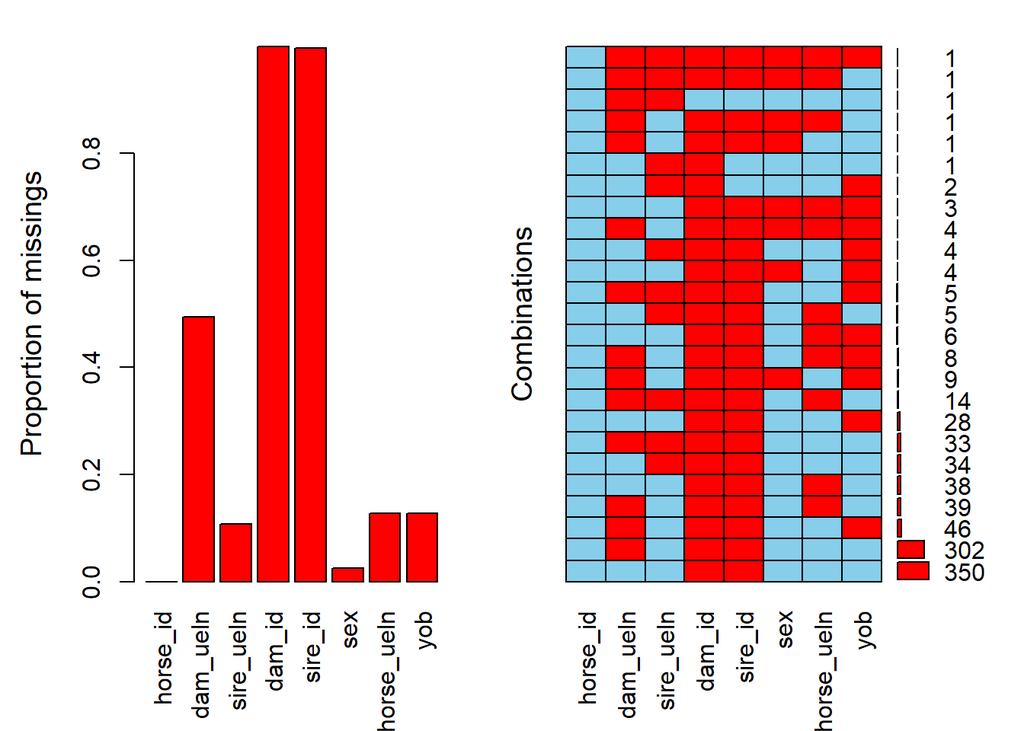

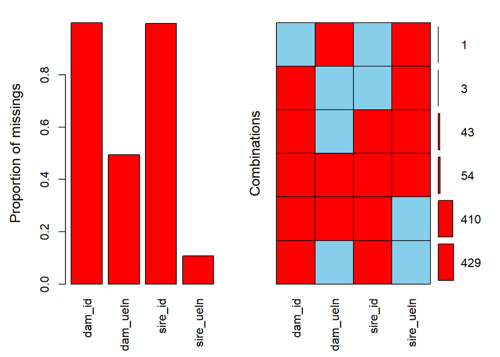

Given that there are no cases where a sire and dam have both a ueln and an id, we can paste these columns together to make the analysis easier. This leaves us with 132 dams and 182 sires in our dataset. Of these, 52 of the dams also have their own record and 91 of the sires have their own record.

```r
ped <- ped %>%
  mutate(dam = coalesce(dam_id, dam_ueln)) %>%
  mutate(sire = coalesce(sire_id, sire_ueln))

length(unique(na.omit(ped$dam)))
```

```
## [1] 132
```

```r
length(unique(na.omit(ped$sire)))
```

```
## [1] 182
```

```r
ped %>%
  filter(!is.na(dam)) %>%
  select(dam) %>%
  filter(dam %in% ped$horse_id | dam %in% ped$horse_ueln) %>%
  distinct() %>%
  count()
```

```
## # A tibble: 1 x 1
##       n
##   <int>
## 1    52
```

```r
ped %>%
  filter(!is.na(sire)) %>%
  filter(sire %in% ped$horse_id | sire %in% ped$horse_ueln) %>%
  select(sire) %>%
  distinct() %>%
  count()
```

```
## # A tibble: 1 x 1
##       n
##   <int>
## 1    91
```

A test of quality is whether the sex is as expected for all of these individuals. Surprisingly, 6 individuals listed as dams are listed as male. Unlike the mares, all of the sires are listed as males.

```r
## dams
dam_ids <- ped %>%
  filter(!is.na(dam)) %>%
  select(dam) %>%
  distinct() %>%
  pull(dam)

dam_records <- ped %>%
  filter(horse_id %in% dam_ids | horse_ueln %in% dam_ids) %>%
  select(horse_id, horse_ueln, sex)

nrow(dam_records)
```

```
## [1] 52
```

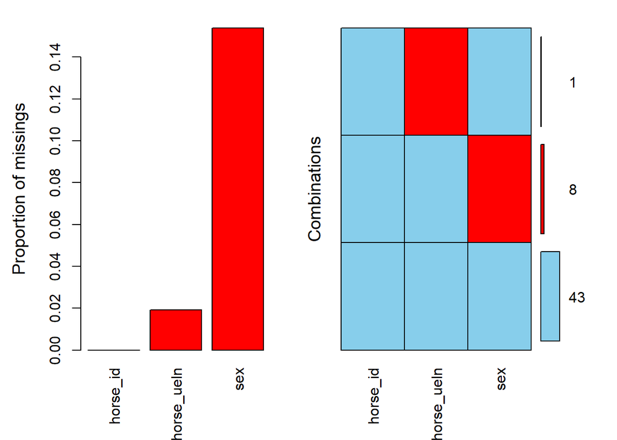

```r
aggr(dam_records, numbers = T, prop = c(T, F))
```

```r
table(dam_records$sex)
```

```
##
##  0  1
## 38  6
```

```r
## sires
sire_ids <- ped %>%
  filter(!is.na(sire)) %>%
  select(sire) %>%
  distinct() %>%
  pull(sire)

sire_records <- ped %>%
  filter(horse_id %in% sire_ids | horse_ueln %in% sire_ids) %>%
  select(horse_id, horse_ueln, sex)

nrow(sire_records)
```

```
## [1] 91
```

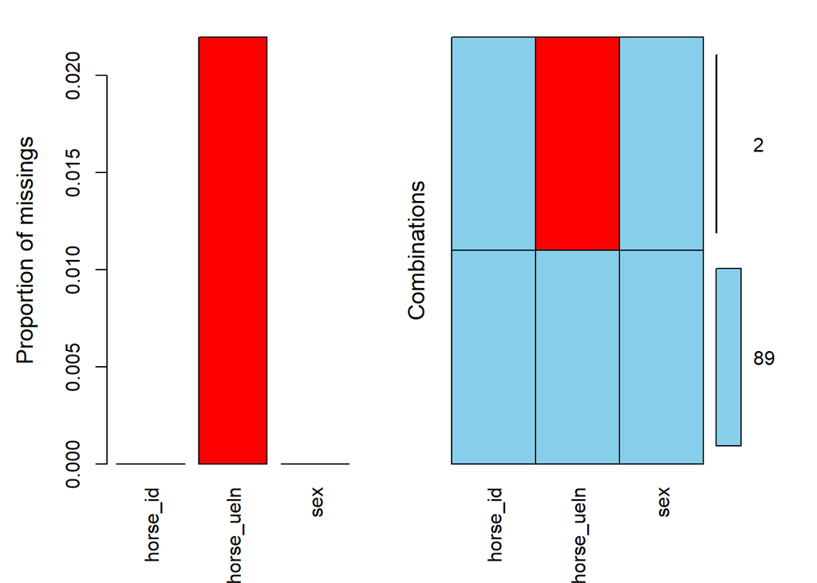

```r
aggr(sire_records, numbers = T, prop = c(T, F))
```

```r
table(sire_records$sex)
```

```
##
##  1
## 91
```

#### Decision to Omit Dam Information

This is the second inconsistency I have observed in this dam data, and thus I have chosen not to take it forward to future analyses. I also remove the now unnecessary `sire_ueln` and `sire_id` columns.

```r
ped_withdams <- ped
ped$dam <- NULL
ped$dam_ueln <- NULL
ped$dam_id <- NULL
ped$sire_ueln <- NULL
ped$sire_id <- NULL
head(ped)
```

```
## # A tibble: 6 x 5
##   horse_id sex   horse_ueln        yob sire
##   <chr>    <chr> <chr>           <dbl> <chr>
## 1 105AH62  0     276409090042107  2007 276409090081903
## 2 103CM31  0     276441411396304  2004 276343430476299
## 3 DEN40739 1     208333200301452  2003 276309090304085
## 4 105BZ34  0     276431310562909  2009 276341410479692
## 5 GER45558 1     276431316886802  2002 276333330610198
## 6 103UX58  1     276441410700406  2006 276441410339001
```

### Ensure Each Sire has a Row

```r
sires_wo_rows <- ped %>%
  filter(!(sire %in% horse_id) & !(sire %in% horse_ueln)) %>%
  select(sire) %>%
  distinct() %>%
  pull()

length(sires_wo_rows)
```

```
## [1] 91
```

```r
ped <- rbind(ped, data.frame(horse_id = NA, sex = 1, horse_ueln = sires_wo_rows, yob = NA, sire = NA))

tail(ped)
```

```
## # A tibble: 6 x 5
##   horse_id sex   horse_ueln        yob sire
##   <chr>    <chr> <chr>           <dbl> <chr>
## 1 <NA>     1     528003199910119    NA <NA>
## 2 <NA>     1     276331310590093    NA <NA>
## 3 <NA>     1     276431316831600    NA <NA>
## 4 <NA>     1     276441410820407    NA <NA>
## 5 <NA>     1     276441410557400    NA <NA>
## 6 <NA>     1     276309090080598    NA <NA>
```

## Clean the Shows Table

To begin, I will assign each show a unique identifier. Seven of the individuals with show results in this table are not included in the pedigree table, and are thus discarded. I also remove team show results, as these are the sum of all individuals in the team.

```r
head(shows)
```

```
##   location event_type                            comp_title horse_id
## 1      NED      CDI-W GP FS - Grand Prix Freestyle to Music  102ZI90
## 2      NED      CDI-W                       GP - Grand Prix  102ZI90
## 3      SWE      CDI5* GP FS - Grand Prix Freestyle to Music  102ZI90
## 4      SWE      CDI5*                       GP - Grand Prix  102ZI90
## 5      GER      CDI-W GP FS - Grand Prix Freestyle to Music  102ZI90
## 6      GER      CDI-W                       GP - Grand Prix  102ZI90
##               dob  sex rider_id position  score
## 1 15 - 07/07/2005 Mare 10011389        1 90.280
## 2 15 - 07/07/2005 Mare 10011389        1 83.565
## 3 15 - 07/07/2005 Mare 10011389        2 89.310
## 4 15 - 07/07/2005 Mare 10011389        1 83.652
## 5 15 - 07/07/2005 Mare 10011389        2 87.240
## 6 15 - 07/07/2005 Mare 10011389        1 81.565
```

```r
summary(shows)
```

```
##    location          event_type         comp_title          horse_id
##  Length:18033       Length:18033       Length:18033       Length:18033
##  Class :character   Class :character   Class :character   Class :character
##  Mode  :character   Mode  :character   Mode  :character   Mode  :character
##      dob                sex              rider_id           position
##  Length:18033       Length:18033       Length:18033       Length:18033
##  Class :character   Class :character   Class :character   Class :character
##  Mode  :character   Mode  :character   Mode  :character   Mode  :character
##     score
##  Length:18033
##  Class :character
##  Mode  :character
```

```r
shows$show_id <- c(1:nrow(shows))
shows$score <- as.numeric(shows$score)
shows <- shows %>%
  filter(horse_id %in% ped$horse_id)

shows %>%
  group_by(comp_title) %>%
  summarise(mean = mean(score, na.rm = T)) %>%
  filter(mean > 100)
```

```
## # A tibble: 1 x 2
##   comp_title           mean
##   <chr>               <dbl>
## 1 Team Classification  139.
```

```r
shows <- shows %>%
  filter(!str_detect(comp_title, "Team"))
```

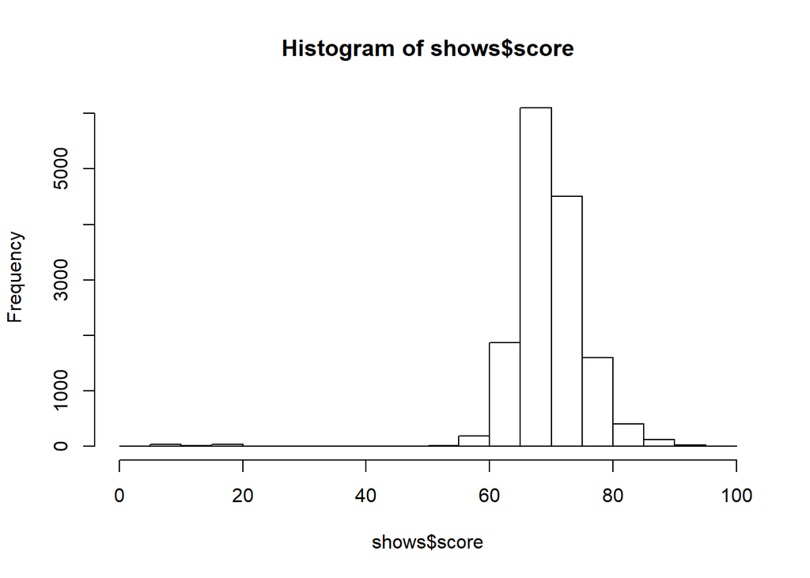

```r
hist(shows$score)
```

```r
shows %>%
  group_by(comp_title) %>%
  summarise(mean = mean(score, na.rm = T)) %>%
  filter(mean < 30)
```

```
## # A tibble: 9 x 2
##   comp_title                 mean
##   <chr>                     <dbl>
## 1 Small Final - YH 6 YO      7.6
## 2 YH 5 Final                16.3
## 3 YH 5 Final - Test for 5-y  9.22
## 4 YH 5 Prel                 15.2
## 5 YH 5 Prel - Preliminary T  8.68
## 6 YH 6 Final                27.1
## 7 YH 6 Final - Test for 6-y  8.61
## 8 YH 6 Prel                 21.9
## 9 YH 6 Prel - Preliminary T  8.12
```

```r
shows %>%
  filter(score < 30)
```

```
##    location event_type                                  comp_title horse_id
## 1       GER  CH-M-YH-D                   YH 6 Final - Test for 6-y  104BD64
## 2       GER  CH-M-YH-D                   YH 6 Prel - Preliminary T  104BD64
## 3       GER  CH-M-YH-D                                  YH 5 Final  104BD64
## 4       GER  CH-M-YH-D                                   YH 5 Prel  104BD64
## 5       GER  CH-M-YH-D                   YH 6 Final - Test for 6-y  104BI66
## 6       GER  CH-M-YH-D                   YH 6 Prel - Preliminary T  104BI66
## 7       GER  CH-M-YH-D                                  YH 5 Final  104BI66
## 8       GER  CH-M-YH-D                                   YH 5 Prel  104BI66
## 9       GER  CH-M-YH-D                                  YH 6 Final  103LO51
## 10      GER  CH-M-YH-D                                   YH 6 Prel  103LO51
## 11      GER  CH-M-YH-D                   YH 6 Final - Test for 6-y  104FC44
## 12      GER  CH-M-YH-D                   YH 6 Prel - Preliminary T  104FC44
## 13      GER  CH-M-YH-D YH 5 Final - Test for 5-year old horses ...  103RQ42
## 14      GER  CH-M-YH-D YH 5 Prel - Preliminary Test for 5-year ...  103RQ42
```

[output cut: 143 more lines]

```r
shows <- shows %>%
  filter(!str_detect(comp_title, "YH"))

summary(shows$score)
```

```
##    Min. 1st Qu.  Median    Mean 3rd Qu.    Max.    NA's
##    0.00   66.56   69.35   69.81   72.61   95.40     517
```

```r
nrow(shows)
```

```
## [1] 14978
```

```r
unique(shows$position)
```

```
##  [1] "1"   "31"  "3"   "4"   "2"   "9"   "16"  "7"   "EL"  "6"   "8"   "13"
## [13] "12"  "10"  "19"  "5"   "11"  "18"  "RET" "21"  "17"  "24"  "25"  "29"
## [25] "14"  "15"  "26"  "20"  "27"  "28"  "WD"  "38"  "23"  "22"  "33"  "35"
## [37] "32"  "55"  "58"  "37"  "65"  "30"  "45"  "DSQ" "34"  NA    "36"  "50"
## [49] "63"  "73"  "74"  "56"  "60"  "39"  "51"  "70"  "41"  "43"  "61"  "76"
## [61] "40"  "47"  "42"  "54"  "44"  "64"  "57"  "59"  "53"  "66"  "84"  "71"
## [73] "62"  "93"
```

```r
shows %>%
  filter(position == "RET" | position == "DSQ" | position == "WD") %>%
  count(position)
```

```
##   position   n
## 1      DSQ   7
## 2      RET 123
## 3       WD 138
```

```r
shows %>%
  filter(!(position == "RET" | position == "DSQ" | position == "WD")) %>%
  filter(is.na(score)) %>%
  count(comp_title)
```

```
##                                     comp_title  n
## 1                    FC - Final Classification 21
## 2                    FEI 3* Grand Prix Special  1
## 3  FEI Dressage Test for 5-Year Old Horses ...  1
## 4                        FEI Freestyle Juniors  1
## 5                               FEI Grand Prix  5
## 6                          FEI Grand Prix - 4*  1
## 7                        FEI Grand Prix - CDIW  1
## 8                       FEI Grand Prix Special  2
## 9                  FEI Grand Prix Special - 4*  1
## 10          FEI Intermediaire I CDI 1*/USEF HP  1
## 11                          FEI Intermediare 1  1
## 12              FEI Intermediare 1 for Amateur  1
## 13                    FEI Intermediare B 16-25  1
## 14                   FEI Intermediare II 16-25  1
```

[output cut: 19 more lines]

```r
shows <- shows %>%
  filter(!str_detect(comp_title, "Final Classification"))

sum(is.na(shows$horse_id))
```

```
## [1] 0
```

```r
sum(is.na(shows$rider_id))
```

```
## [1] 0
```

The sex and yob columns need to be cleaned as for `ped`.

```r
shows <- shows %>%
  mutate(sex=replace(sex, sex == "Mare", "0")) %>%
  mutate(sex=replace(sex, sex == "Stallion", "1")) %>%
  mutate(sex=replace(sex, sex == "Gelding", "1")) %>%
  mutate(sex=replace(sex, sex == "Male", "1")) %>%
  mutate(sex=replace(sex, sex == "Female", "0"))

table(shows$sex)
```

```
##
##     0     1
##  2575 12296
```

```r
shows$dob <- str_trim(str_remove(shows$dob, "^[^-]*-"))

tail(shows$dob)
```

```
## [1] "21/05/2008" "21/05/2008" "21/05/2008" "21/05/2008" "21/05/2008"
## [6] "21/05/2008"
```

```r
shows$yob <- year(dmy(shows$dob))

tail(shows$yob)
```

```
## [1] 2008 2008 2008 2008 2008 2008
```

The pedigree and the shows column agree about the year of birth and the sex of every horse.

```r
ped %>%
  inner_join(., shows, by = "horse_id") %>%
  select(horse_id, sex.y, sex.x, yob.x, yob.y) %>%
  distinct() %>%
  count(horse_id) %>%
  filter(n > 1)
```

```
## # A tibble: 0 x 2
## # ... with 2 variables: horse_id <chr>, n <int>
```

```r
dbWriteTable(conn, "clean_pedigree", ped, overwrite = T)
dbWriteTable(conn, "clean_shows", shows, overwrite = T)

dbDisconnect(conn)
```